# Hessian Fly Yield Trial Analysis

Zachary Winn

2022-07-13

# Introduction

Here is all the code that was used in the present study. PIT and NOPPT are not normal. They are zero-inflated, continuous, positive non-integers. There are no available models which can handle this data in a way that is amenable to contrast in lme4. Therefore, I am going to apply a Inverse hyperbolic sine (IHS) transformation. The transformation is defined below:

$$f(y,\theta)=\frac{sinh^{-1}(\theta y)}{\theta}=log(\theta y+(\theta^{2}
y^{2}+1)^\frac{1}{2})$$
Where y is a response of any distribution and theta is a value which results in the best fit of the response to a normal distribution. $\theta$ may be estimated empirically. This may be done by using the log-likelihood to best estimate which value of theta results in the best fit of the data. This can be expressed as in Burbidge et al (1988) (https://doi.org/10.2307/2288929).

$$-\frac{1}{2}\sum log(1+\theta^2y^2_i)$$
Where $\theta$ is any value of $\theta\ge0$ and $y_i$ is the $i^{th}$ observation of response y. Essentially, many values of $\theta$ are considered, and the one which maximizes the log-likelihood is used as $\theta$ in the previous transformation.

# Reading in the Data

Here I read in the data and tranform the data

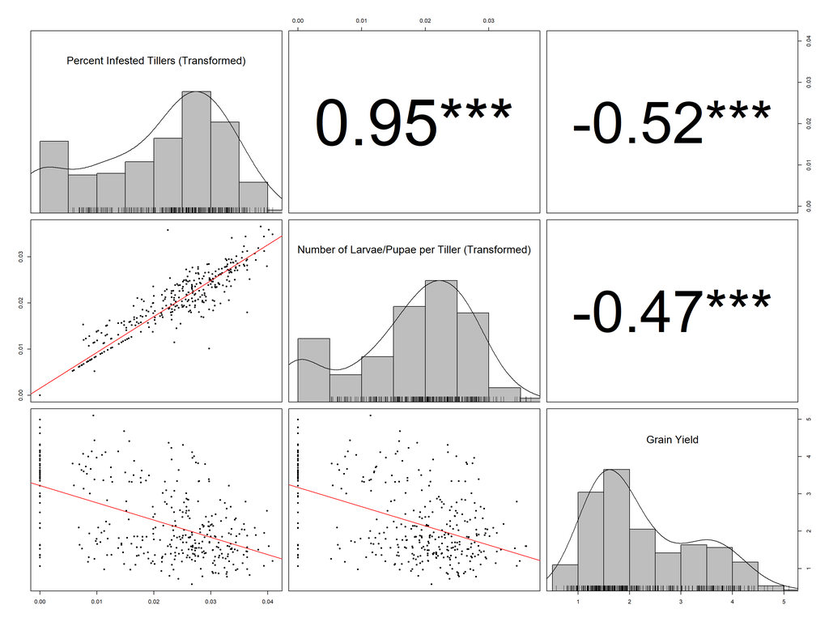

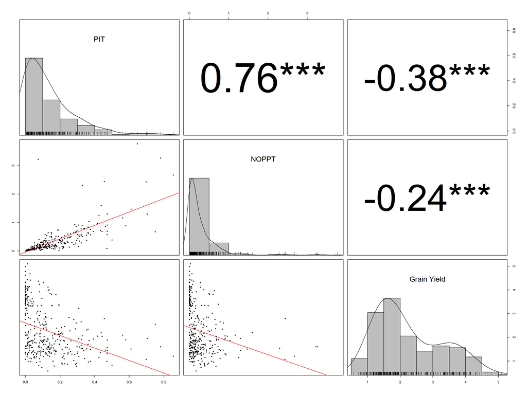

# Running Single Environment Models

Here I run the following split-plot mixed linear model:

$$y_{ijk}=\mu+G_i+gr_{ik}+T_j+tr_{jk}+GT_{ij}+\varepsilon_{ijk}$$

```r
# set up models
traits <- c("PIT_T", "NOPPT_T", "Grain Yield")
env <- c(unique(pheno$Location))
preds <- pheno %>%
    dplyr::select(Genotype, Treatment) %>%
    distinct()

# library
library(lme4)
library(lmerTest)
library(emmeans)
library(knitr)
library(multcomp)
```

```r
# make an empty frame for results
anova_results <- c()
g_by_t_means <- c()
g_by_t_contrast <- c()

# display G*E graphs?
vis_on = 0

# Run Models
for (i in traits) {
    for (j in env) {

        # pull data for location and trait
        loc <- pheno[pheno$Location == j, ]
        loc <- loc %>%
            dplyr::select(Rep, Genotype, Treatment, all_of(i))
        colnames(loc)[4] = "Y"

        if (sum(is.na(loc[, "Y"])) == nrow(loc)) {
            # check if data was taken

            # print if there is no data
            print(paste("**** No data was taken for", i, "in", j, "****"))

        } else {

            # print to announce
            print(paste("*** Running model for", i, "in", j, "***", sep = " "))

            # run mixed linear model
            mlm <- lmer(Y ~ Genotype + Treatment + Genotype:Treatment + (1 | Rep), data = loc)

            # print ANOVA and summary of model
            print("*** Showing ANOVA Table ***")
            print(anova(mlm))
            # print('*** Showing Summary ***') print(summary(mlm))
            print("*** Showing Random Effect Estimates ***")
            print(ranef(mlm))

            # pull G-by-E estimates
            a <- summary(emmeans(mlm, ~Genotype:Treatment, type = "response"))
            a <- a %>%
                mutate(Location = all_of(j), Trait = all_of(i)) %>%
                rename(Estimate = emmean, DF = df, `Lower Confidence Level` = lower.CL, `Upper Confidence Level` = upper.CL) %>%
                dplyr::select(Genotype, Treatment, Trait, Location, Estimate, DF, `Lower Confidence Level`, `Upper Confidence Level`)

            # bind in G-by-E estimates
            g_by_t_means <- rbind(g_by_t_means, a)

            # print means
            a <- a[order(a$Genotype), ]
            print(kable(a, caption = paste("Means with confidence intervals of Genotype*Treatment interaction for", i, "in", j), row.names = F, digits = 2))

            # preform pairwise contrast
            a <- emmeans(mlm, ~Genotype:Treatment)
            a <- summary(contrast(a, method = "pairwise"))
            a <- a %>%
                separate(contrast, into = c("Combination_1", "Combination_2"), sep = " - ") %>%
                filter(Combination_1 == "Jamestown Absent" & Combination_2 == "Jamestown Present" | Combination_1 == "LA03136E71 Absent" & Combination_2 == "LA03136E71 Present" | Combination_1 == "(NC11546-14 Absent)" & Combination_2 == "(NC11546-14 Present)" | Combination_1 == "Shirley Absent" & Combination_2 == "Shirley Present" | Combination_1 == "SS8641 Absent" & Combination_2 == "SS8641 Present" | Combination_1 == "USG3404 Absent" & Combination_2 == "USG3404 Present")

            # print results and bind in
            a$trait = i
            a$location = j
            a <- a %>%
                dplyr::select(Combination_1, Combination_2, trait, location, estimate, SE, df, t.ratio, p.value) %>%
                rename(`Combination 1` = Combination_1, `Combination 2` = Combination_2, Trait = trait, Location = location, Estimate = estimate, SE = SE, DF = df, `T-Ratio` = t.ratio, `P(>T)` = p.value)

            print(kable(a, caption = paste("Pairwise contrast for Genotype*Treatment for", i, "in", j), digits = 2))
            g_by_t_contrast <- rbind(g_by_t_contrast, a)

            if (vis_on == 1) {

                # display G*E Graph
                a <- summary(emmeans(mlm, ~Genotype:Treatment))
                a <- ggplot(data = a, aes(x = Treatment, y = emmean, color = Genotype)) + geom_point() + geom_line(aes(group = Genotype)) + labs(title = paste("Genotype*Treatment Interaction Plot for", i, "in", j), y = "")
                print(a)

                # pull ANOVA table results
                a <- anova(mlm)
                a <- data.frame(Effect = row.names(a), Location = j, Trait = i, `F Value` = a$`F value`, `P(>F)` = a$`Pr(>F)`, check.names = F)
                a <- a %>%
                  dplyr::select(Location, Trait, Effect, `F Value`, `P(>F)`)
                anova_results <- rbind(anova_results, a)

                # print
                print("*** Analysis finsihed - moving on to next trait ***")
                print("")
                print("")

            } else {

                # pull ANOVA table results
                a <- anova(mlm)
                a <- data.frame(Effect = row.names(a), Location = j, Trait = i, `F Value` = a$`F value`, `P(>F)` = a$`Pr(>F)`, check.names = F)
                a <- a %>%
                  dplyr::select(Location, Trait, Effect, `F Value`, `P(>F)`)
                anova_results <- rbind(anova_results, a)

                # print
                print("*** Analysis finsihed - moving on to next trait ***")
                print("")
                print("")

            }
        }
    }
}
```

```
## [1] "*** Running model for PIT_T in HUG21 ***"
## [1] "*** Showing ANOVA Table ***"
## Type III Analysis of Variance Table with Satterthwaite's method
##                       Sum Sq    Mean Sq NumDF DenDF F value    Pr(>F)
## Genotype           0.0032945 0.00065891     5    55 16.5109 6.291e-10 ***
## Treatment          0.0024911 0.00249108     1    55 62.4216 1.266e-10 ***
## Genotype:Treatment 0.0004732 0.00009464     5    55  2.3715   0.05093 .
## ---
## Signif. codes:  0 '***' 0.001 '**' 0.01 '*' 0.05 '.' 0.1 ' ' 1
## [1] "*** Showing Random Effect Estimates ***"
## $Rep
##     (Intercept)
## 1  1.085484e-05
## 2 -2.083474e-04
## 3  6.681527e-06
## 4  1.902300e-04
## 5 -8.336183e-05
## 6  8.394287e-05
##
## with conditional variances for "Rep"
##
##
## Table: Means with confidence intervals of Genotype*Treatment interaction for PIT_T in HUG21
##
## |Genotype   |Treatment |Trait |Location | Estimate|    DF| Lower Confidence Level| Upper Confidence Level|
## |:----------|:---------|:-----|:--------|--------:|-----:|----------------------:|----------------------:|
## |Jamestown  |Absent    |PIT_T |HUG21    |     0.02| 59.97|                   0.02|                   0.03|
## |Jamestown  |Present   |PIT_T |HUG21    |     0.01| 59.97|                   0.00|                   0.01|
## |LA03136E71 |Absent    |PIT_T |HUG21    |     0.02| 59.97|                   0.01|                   0.02|
## |LA03136E71 |Present   |PIT_T |HUG21    |     0.00| 59.97|                   0.00|                   0.01|
## |NC11546-14 |Absent    |PIT_T |HUG21    |     0.01| 59.97|                   0.00|                   0.01|
## |NC11546-14 |Present   |PIT_T |HUG21    |     0.00| 59.97|                   0.00|                   0.01|
## |Shirley    |Absent    |PIT_T |HUG21    |     0.03| 59.97|                   0.02|                   0.03|
## |Shirley    |Present   |PIT_T |HUG21    |     0.01| 59.97|                   0.01|                   0.02|
## |SS8641     |Absent    |PIT_T |HUG21    |     0.03| 59.97|                   0.02|                   0.03|
## |SS8641     |Present   |PIT_T |HUG21    |     0.02| 59.97|                   0.01|                   0.02|
## |USG3404    |Absent    |PIT_T |HUG21    |     0.03| 59.97|                   0.02|                   0.03|
## |USG3404    |Present   |PIT_T |HUG21    |     0.02| 59.97|                   0.02|                   0.03|
##
##
```

[output cut: 54 more lines]

```
##
## Table: Pairwise contrast for Genotype*Treatment for PIT_T in HUG22
##
## |Combination 1       |Combination 2        |Trait |Location | Estimate| SE|   DF| T-Ratio| P(>T)|
## |:-------------------|:--------------------|:-----|:--------|--------:|--:|----:|-------:|-----:|
## |Jamestown Absent    |Jamestown Present    |PIT_T |HUG22    |     0.01|  0| 75.0|    2.03|  0.67|
## |LA03136E71 Absent   |LA03136E71 Present   |PIT_T |HUG22    |     0.01|  0| 75.0|    2.46|  0.38|
## |(NC11546-14 Absent) |(NC11546-14 Present) |PIT_T |HUG22    |     0.00|  0| 75.4|   -0.14|  1.00|
## |Shirley Absent      |Shirley Present      |PIT_T |HUG22    |     0.00|  0| 75.4|    0.83|  1.00|
## |SS8641 Absent       |SS8641 Present       |PIT_T |HUG22    |     0.01|  0| 75.0|    1.63|  0.89|
## |USG3404 Absent      |USG3404 Present      |PIT_T |HUG22    |     0.01|  0| 75.0|    2.23|  0.53|
## [1] "*** Analysis finsihed - moving on to next trait ***"
## [1] ""
## [1] ""
## [1] "*** Running model for PIT_T in CUN22 ***"
```

```
## boundary (singular) fit: see help('isSingular')
```

```
## [1] "*** Showing ANOVA Table ***"
## Type III Analysis of Variance Table with Satterthwaite's method
##                       Sum Sq   Mean Sq NumDF DenDF F value Pr(>F)
## Genotype           0.0088950 1.779e-03     5    83 31.6748 <2e-16 ***
## Treatment          0.0000135 1.347e-05     1    83  0.2398 0.6257
## Genotype:Treatment 0.0001054 2.107e-05     5    83  0.3752 0.8644
## ---
## Signif. codes:  0 '***' 0.001 '**' 0.01 '*' 0.05 '.' 0.1 ' ' 1
## [1] "*** Showing Random Effect Estimates ***"
## $Rep
##     (Intercept)
## 1  1.694457e-17
## 2  9.009569e-18
## 3 -3.335035e-19
## 4 -1.910985e-18
## 5 -4.529288e-18
## 6 -1.379412e-17
## 7  2.552526e-18
## 8 -7.938766e-18
##
## with conditional variances for "Rep"
##
##
## Table: Means with confidence intervals of Genotype*Treatment interaction for PIT_T in CUN22
##
## |Genotype   |Treatment |Trait |Location | Estimate| DF| Lower Confidence Level| Upper Confidence Level|
## |:----------|:---------|:-----|:--------|--------:|--:|----------------------:|----------------------:|
## |Jamestown  |Absent    |PIT_T |CUN22    |     0.03| 83|                   0.03|                   0.04|
## |Jamestown  |Present   |PIT_T |CUN22    |     0.03| 83|                   0.02|                   0.03|
## |LA03136E71 |Absent    |PIT_T |CUN22    |     0.01| 83|                   0.01|                   0.02|
## |LA03136E71 |Present   |PIT_T |CUN22    |     0.02| 83|                   0.01|                   0.02|
## |NC11546-14 |Absent    |PIT_T |CUN22    |     0.00| 83|                   0.00|                   0.01|
## |NC11546-14 |Present   |PIT_T |CUN22    |     0.00| 83|                   0.00|                   0.01|
## |Shirley    |Absent    |PIT_T |CUN22    |     0.03| 83|                   0.03|                   0.04|
## |Shirley    |Present   |PIT_T |CUN22    |     0.03| 83|                   0.02|                   0.03|
## |SS8641     |Absent    |PIT_T |CUN22    |     0.03| 83|                   0.02|                   0.03|
## |SS8641     |Present   |PIT_T |CUN22    |     0.03| 83|                   0.02|                   0.03|
## |USG3404    |Absent    |PIT_T |CUN22    |     0.03| 83|                   0.02|                   0.04|
## |USG3404    |Present   |PIT_T |CUN22    |     0.03| 83|                   0.02|                   0.03|
##
```

[output cut: 55 more lines]

```
##
## Table: Pairwise contrast for Genotype*Treatment for PIT_T in CAS22
##
## |Combination 1       |Combination 2        |Trait |Location | Estimate| SE|    DF| T-Ratio| P(>T)|
## |:-------------------|:--------------------|:-----|:--------|--------:|--:|-----:|-------:|-----:|
## |Jamestown Absent    |Jamestown Present    |PIT_T |CAS22    |     0.00|  0| 76.00|    1.11|  0.99|
## |LA03136E71 Absent   |LA03136E71 Present   |PIT_T |CAS22    |     0.01|  0| 76.00|    1.76|  0.83|
## |(NC11546-14 Absent) |(NC11546-14 Present) |PIT_T |CAS22    |     0.00|  0| 76.74|    0.88|  1.00|
## |Shirley Absent      |Shirley Present      |PIT_T |CAS22    |     0.01|  0| 76.00|    2.51|  0.35|
## |SS8641 Absent       |SS8641 Present       |PIT_T |CAS22    |     0.00|  0| 76.00|    0.79|  1.00|
## |USG3404 Absent      |USG3404 Present      |PIT_T |CAS22    |     0.00|  0| 76.00|    0.18|  1.00|
## [1] "*** Analysis finsihed - moving on to next trait ***"
## [1] ""
## [1] ""
## [1] "*** Running model for NOPPT_T in HUG21 ***"
```

```
## boundary (singular) fit: see help('isSingular')
```

```
## [1] "*** Showing ANOVA Table ***"
## Type III Analysis of Variance Table with Satterthwaite's method
##                        Sum Sq    Mean Sq NumDF DenDF F value    Pr(>F)
## Genotype           0.00245575 0.00049115     5    60 12.9977 1.413e-08 ***
## Treatment          0.00227459 0.00227459     1    60 60.1942 1.266e-10 ***
## Genotype:Treatment 0.00037482 0.00007496     5    60  1.9838   0.09399 .
## ---
## Signif. codes:  0 '***' 0.001 '**' 0.01 '*' 0.05 '.' 0.1 ' ' 1
## [1] "*** Showing Random Effect Estimates ***"
## $Rep
##   (Intercept)
## 1           0
## 2           0
## 3           0
## 4           0
## 5           0
## 6           0
##
## with conditional variances for "Rep"
##
##
## Table: Means with confidence intervals of Genotype*Treatment interaction for NOPPT_T in HUG21
##
## |Genotype   |Treatment |Trait   |Location | Estimate| DF| Lower Confidence Level| Upper Confidence Level|
## |:----------|:---------|:-------|:--------|--------:|--:|----------------------:|----------------------:|
## |Jamestown  |Absent    |NOPPT_T |HUG21    |     0.02| 60|                   0.02|                   0.03|
## |Jamestown  |Present   |NOPPT_T |HUG21    |     0.01| 60|                   0.00|                   0.01|
## |LA03136E71 |Absent    |NOPPT_T |HUG21    |     0.02| 60|                   0.02|                   0.03|
## |LA03136E71 |Present   |NOPPT_T |HUG21    |     0.00| 60|                   0.00|                   0.01|
## |NC11546-14 |Absent    |NOPPT_T |HUG21    |     0.01| 60|                   0.00|                   0.01|
## |NC11546-14 |Present   |NOPPT_T |HUG21    |     0.00| 60|                   0.00|                   0.01|
## |Shirley    |Absent    |NOPPT_T |HUG21    |     0.02| 60|                   0.02|                   0.03|
## |Shirley    |Present   |NOPPT_T |HUG21    |     0.01| 60|                   0.01|                   0.02|
## |SS8641     |Absent    |NOPPT_T |HUG21    |     0.03| 60|                   0.02|                   0.03|
## |SS8641     |Present   |NOPPT_T |HUG21    |     0.02| 60|                   0.01|                   0.02|
## |USG3404    |Absent    |NOPPT_T |HUG21    |     0.03| 60|                   0.02|                   0.03|
## |USG3404    |Present   |NOPPT_T |HUG21    |     0.02| 60|                   0.01|                   0.02|
##
##
## Table: Pairwise contrast for Genotype*Treatment for NOPPT_T in HUG21
```

[output cut: 108 more lines]

```
##
## Table: Pairwise contrast for Genotype*Treatment for NOPPT_T in CUN22
##
## |Combination 1       |Combination 2        |Trait   |Location | Estimate| SE|    DF| T-Ratio| P(>T)|
## |:-------------------|:--------------------|:-------|:--------|--------:|--:|-----:|-------:|-----:|
## |Jamestown Absent    |Jamestown Present    |NOPPT_T |CUN22    |        0|  0| 76.01|    1.49|  0.94|
## |LA03136E71 Absent   |LA03136E71 Present   |NOPPT_T |CUN22    |        0|  0| 76.79|   -0.13|  1.00|
## |(NC11546-14 Absent) |(NC11546-14 Present) |NOPPT_T |CUN22    |        0|  0| 76.01|    0.11|  1.00|
## |Shirley Absent      |Shirley Present      |NOPPT_T |CUN22    |        0|  0| 76.01|    0.77|  1.00|
## |SS8641 Absent       |SS8641 Present       |NOPPT_T |CUN22    |        0|  0| 76.01|   -0.65|  1.00|
## |USG3404 Absent      |USG3404 Present      |NOPPT_T |CUN22    |        0|  0| 76.01|   -0.34|  1.00|
## [1] "*** Analysis finsihed - moving on to next trait ***"
## [1] ""
## [1] ""
## [1] "*** Running model for NOPPT_T in CAS22 ***"
```

```
## boundary (singular) fit: see help('isSingular')
```

```
## [1] "*** Showing ANOVA Table ***"
## Type III Analysis of Variance Table with Satterthwaite's method
##                       Sum Sq    Mean Sq NumDF DenDF F value    Pr(>F)
## Genotype           0.0035801 0.00071602     5    83 16.2748 3.672e-11 ***
## Treatment          0.0004963 0.00049633     1    83 11.2814  0.001184 **
## Genotype:Treatment 0.0001290 0.00002581     5    83  0.5866  0.710201
## ---
## Signif. codes:  0 '***' 0.001 '**' 0.01 '*' 0.05 '.' 0.1 ' ' 1
## [1] "*** Showing Random Effect Estimates ***"
## $Rep
##     (Intercept)
## 1  5.625412e-21
## 2 -8.998147e-21
## 3  2.564579e-21
## 4  1.512263e-21
## 5 -5.174977e-21
## 6  1.771510e-21
## 7  4.904471e-21
## 8 -2.205111e-21
##
## with conditional variances for "Rep"
##
##
## Table: Means with confidence intervals of Genotype*Treatment interaction for NOPPT_T in CAS22
##
## |Genotype   |Treatment |Trait   |Location | Estimate| DF| Lower Confidence Level| Upper Confidence Level|
## |:----------|:---------|:-------|:--------|--------:|--:|----------------------:|----------------------:|
## |Jamestown  |Absent    |NOPPT_T |CAS22    |     0.02| 83|                   0.02|                   0.03|
## |Jamestown  |Present   |NOPPT_T |CAS22    |     0.02| 83|                   0.01|                   0.02|
## |LA03136E71 |Absent    |NOPPT_T |CAS22    |     0.02| 83|                   0.01|                   0.02|
## |LA03136E71 |Present   |NOPPT_T |CAS22    |     0.01| 83|                   0.00|                   0.01|
## |NC11546-14 |Absent    |NOPPT_T |CAS22    |     0.01| 83|                   0.00|                   0.01|
## |NC11546-14 |Present   |NOPPT_T |CAS22    |     0.00| 83|                   0.00|                   0.01|
## |Shirley    |Absent    |NOPPT_T |CAS22    |     0.03| 83|                   0.02|                   0.03|
## |Shirley    |Present   |NOPPT_T |CAS22    |     0.02| 83|                   0.01|                   0.02|
## |SS8641     |Absent    |NOPPT_T |CAS22    |     0.02| 83|                   0.02|                   0.03|
## |SS8641     |Present   |NOPPT_T |CAS22    |     0.02| 83|                   0.01|                   0.02|
## |USG3404    |Absent    |NOPPT_T |CAS22    |     0.02| 83|                   0.02|                   0.03|
## |USG3404    |Present   |NOPPT_T |CAS22    |     0.02| 83|                   0.02|                   0.03|
##
```

[output cut: 163 more lines]

```
##
## Table: Pairwise contrast for Genotype*Treatment for Grain Yield in CUN22
##
## |Combination 1       |Combination 2        |Trait       |Location | Estimate|   SE|    DF| T-Ratio| P(>T)|
## |:-------------------|:--------------------|:-----------|:--------|--------:|----:|-----:|-------:|-----:|
## |Jamestown Absent    |Jamestown Present    |Grain Yield |CUN22    |    -0.38| 0.19| 76.29|   -2.02|  0.68|
## |LA03136E71 Absent   |LA03136E71 Present   |Grain Yield |CUN22    |    -0.06| 0.18| 76.00|   -0.31|  1.00|
## |(NC11546-14 Absent) |(NC11546-14 Present) |Grain Yield |CUN22    |    -0.06| 0.18| 76.00|   -0.33|  1.00|
## |Shirley Absent      |Shirley Present      |Grain Yield |CUN22    |    -0.68| 0.18| 76.00|   -3.72|  0.02|
## |SS8641 Absent       |SS8641 Present       |Grain Yield |CUN22    |    -0.22| 0.18| 76.00|   -1.22|  0.99|
## |USG3404 Absent      |USG3404 Present      |Grain Yield |CUN22    |    -0.26| 0.18| 76.00|   -1.42|  0.96|
## [1] "*** Analysis finsihed - moving on to next trait ***"
## [1] ""
## [1] ""
## [1] "*** Running model for Grain Yield in CAS22 ***"
```

```
## boundary (singular) fit: see help('isSingular')
```

```
## [1] "*** Showing ANOVA Table ***"
## Type III Analysis of Variance Table with Satterthwaite's method
##                    Sum Sq Mean Sq NumDF DenDF F value    Pr(>F)
## Genotype           42.743  8.5487     5    84 78.5714 < 2.2e-16 ***
## Treatment           1.826  1.8260     1    84 16.7826 9.614e-05 ***
## Genotype:Treatment  0.910  0.1820     5    84  1.6725    0.1502
## ---
## Signif. codes:  0 '***' 0.001 '**' 0.01 '*' 0.05 '.' 0.1 ' ' 1
## [1] "*** Showing Random Effect Estimates ***"
## $Rep
##   (Intercept)
## 1           0
## 2           0
## 3           0
## 4           0
## 5           0
## 6           0
## 7           0
## 8           0
##
## with conditional variances for "Rep"
##
##
## Table: Means with confidence intervals of Genotype*Treatment interaction for Grain Yield in CAS22
##
## |Genotype   |Treatment |Trait       |Location | Estimate| DF| Lower Confidence Level| Upper Confidence Level|
## |:----------|:---------|:-----------|:--------|--------:|--:|----------------------:|----------------------:|
## |Jamestown  |Absent    |Grain Yield |CAS22    |     1.20| 84|                   0.97|                   1.44|
## |Jamestown  |Present   |Grain Yield |CAS22    |     1.54| 84|                   1.31|                   1.77|
## |LA03136E71 |Absent    |Grain Yield |CAS22    |     1.52| 84|                   1.28|                   1.75|
## |LA03136E71 |Present   |Grain Yield |CAS22    |     1.53| 84|                   1.30|                   1.76|
## |NC11546-14 |Absent    |Grain Yield |CAS22    |     3.19| 84|                   2.96|                   3.42|
## |NC11546-14 |Present   |Grain Yield |CAS22    |     3.43| 84|                   3.20|                   3.66|
## |Shirley    |Absent    |Grain Yield |CAS22    |     1.81| 84|                   1.58|                   2.04|
## |Shirley    |Present   |Grain Yield |CAS22    |     2.46| 84|                   2.23|                   2.70|
## |SS8641     |Absent    |Grain Yield |CAS22    |     2.16| 84|                   1.92|                   2.39|
## |SS8641     |Present   |Grain Yield |CAS22    |     2.39| 84|                   2.15|                   2.62|
## |USG3404    |Absent    |Grain Yield |CAS22    |     1.41| 84|                   1.18|                   1.65|
## |USG3404    |Present   |Grain Yield |CAS22    |     1.60| 84|                   1.37|                   1.83|
##
##
## Table: Pairwise contrast for Genotype*Treatment for Grain Yield in CAS22
##
## |Combination 1       |Combination 2        |Trait       |Location | Estimate|   SE| DF| T-Ratio| P(>T)|
## |:-------------------|:--------------------|:-----------|:--------|--------:|----:|--:|-------:|-----:|
## |Jamestown Absent    |Jamestown Present    |Grain Yield |CAS22    |    -0.34| 0.16| 77|   -2.05|  0.66|
## |LA03136E71 Absent   |LA03136E71 Present   |Grain Yield |CAS22    |    -0.01| 0.16| 77|   -0.08|  1.00|
## |(NC11546-14 Absent) |(NC11546-14 Present) |Grain Yield |CAS22    |    -0.24| 0.16| 77|   -1.43|  0.95|
## |Shirley Absent      |Shirley Present      |Grain Yield |CAS22    |    -0.65| 0.16| 77|   -3.96|  0.01|
## |SS8641 Absent       |SS8641 Present       |Grain Yield |CAS22    |    -0.23| 0.16| 77|   -1.40|  0.96|
## |USG3404 Absent      |USG3404 Present      |Grain Yield |CAS22    |    -0.18| 0.16| 77|   -1.11|  0.99|
## [1] "*** Analysis finsihed - moving on to next trait ***"
## [1] ""
## [1] ""
```

```r
# write out results
write.csv(anova_results, "single_environment_anova_results.csv", row.names = F)

write.csv(g_by_t_means, "g_by_t_single_environment_means.csv", row.names = F)

write.csv(g_by_t_contrast, "g_by_t_single_environment_contrast.csv", row.names = F)
```

## Across Environments

Here I run an across environments analysis with the following model:

$$y_{ijkl}=\mu+G_i+T_j+E_k+GT_{ij}+GE_{ik}+ET_{jk}+GTE_{ijk}+e(r)_{kl}+\varepsilon_{ijkl}$$

```
## [1] "Analyzing PIT_T"
## [1] "*** Showing ANOVA Table ***"
## Type III Analysis of Variance Table with Satterthwaite's method
##                                   Sum Sq   Mean Sq NumDF   DenDF F value    Pr(>F)
## Genotype                       0.0191540 0.0038308     5 282.534 70.3057 < 2.2e-16 ***
## Treatment                      0.0028475 0.0028475     1 282.504 52.2590 4.564e-12 ***
## Environment                    0.0022647 0.0007549     3  26.032 13.8543 1.355e-05 ***
## Genotype:Treatment             0.0004365 0.0000873     5 282.534  1.6021   0.15952
## Genotype:Environment           0.0016094 0.0001073    15 282.547  1.9691   0.01742 *
## Treatment:Environment          0.0012461 0.0004154     3 282.524  7.6233 6.430e-05 ***
## Genotype:Treatment:Environment 0.0006380 0.0000425    15 282.547  0.7806   0.69895
## ---
## Signif. codes:  0 '***' 0.001 '**' 0.01 '*' 0.05 '.' 0.1 ' ' 1
## [1] "*** Showing Random Effect Estimates ***"
## $`Environment:Rep`
##           (Intercept)
## CAS22:1  4.834296e-04
## CAS22:2 -1.084973e-03
## CAS22:3  4.853020e-04
## CAS22:4 -3.931617e-05
## CAS22:5 -2.954642e-04
## CAS22:6  1.343712e-04
## CAS22:7  5.375535e-04
## CAS22:8 -2.209033e-04
## CUN22:1  6.613347e-04
## CUN22:2  3.517289e-04
## CUN22:3 -1.281675e-05
## CUN22:4 -7.593292e-05
## CUN22:5 -1.765268e-04
## CUN22:6 -5.380198e-04
## CUN22:7  9.978959e-05
## CUN22:8 -3.095569e-04
## HUG21:1  3.250961e-05
## HUG21:2 -6.239883e-04
## HUG21:3  2.001079e-05
## HUG21:4  5.697278e-04
## HUG21:5 -2.496639e-04
## HUG21:6  2.514040e-04
## HUG22:1 -1.315199e-03
## HUG22:2 -8.409109e-05
## HUG22:3  5.833887e-04
## HUG22:4  8.595854e-04
## HUG22:5  8.646052e-05
## HUG22:6 -2.701836e-04
## HUG22:7 -2.182062e-04
## HUG22:8  3.582455e-04
##
## with conditional variances for "Environment:Rep"
```

```
## NOTE: Results may be misleading due to involvement in interactions
```

```
##
##
## Table: Means with confidence intervals of Genotype*Treatment interaction for PIT_T
##
## |Genotype   |Treatment | emmean| SE|     df| lower.CL| upper.CL|
## |:----------|:---------|------:|--:|------:|--------:|--------:|
## |Jamestown  |Absent    |   0.03|  0| 306.31|     0.02|     0.03|
## |Jamestown  |Present   |   0.02|  0| 306.31|     0.02|     0.02|
## |LA03136E71 |Absent    |   0.02|  0| 306.50|     0.02|     0.02|
## |LA03136E71 |Present   |   0.01|  0| 306.31|     0.01|     0.01|
## |NC11546-14 |Absent    |   0.01|  0| 306.31|     0.01|     0.01|
## |NC11546-14 |Present   |   0.01|  0| 306.67|     0.00|     0.01|
## |Shirley    |Absent    |   0.03|  0| 306.31|     0.03|     0.03|
## |Shirley    |Present   |   0.02|  0| 306.50|     0.02|     0.03|
## |SS8641     |Absent    |   0.03|  0| 306.31|     0.03|     0.03|
## |SS8641     |Present   |   0.02|  0| 306.31|     0.02|     0.03|
## |USG3404    |Absent    |   0.03|  0| 306.31|     0.03|     0.03|
## |USG3404    |Present   |   0.02|  0| 306.31|     0.02|     0.03|
```

```
## NOTE: Results may be misleading due to involvement in interactions
```

```
##
##
## Table: Pairwise contrast for Genotype*Treatment for PIT_T
##
## |Combination_1       |Combination_2        | estimate| SE|     df| t.ratio| p.value|
## |:-------------------|:--------------------|--------:|--:|------:|-------:|-------:|
## |Jamestown Absent    |Jamestown Present    |     0.01|  0| 282.02|    4.27|    0.00|
## |LA03136E71 Absent   |LA03136E71 Present   |     0.01|  0| 282.64|    4.04|    0.00|
## |(NC11546-14 Absent) |(NC11546-14 Present) |     0.00|  0| 283.24|    1.06|    1.00|
## |Shirley Absent      |Shirley Present      |     0.01|  0| 282.64|    3.75|    0.01|
## |SS8641 Absent       |SS8641 Present       |     0.00|  0| 282.02|    2.51|    0.34|
## |USG3404 Absent      |USG3404 Present      |     0.00|  0| 282.02|    2.08|    0.64|
## [1] "Analyzing NOPPT_T"
## [1] "*** Showing ANOVA Table ***"
## Type III Analysis of Variance Table with Satterthwaite's method
##                                   Sum Sq    Mean Sq NumDF   DenDF F value    Pr(>F)
## Genotype                       0.0130386 0.00260773     5 282.429 71.7573 < 2.2e-16 ***
## Treatment                      0.0023909 0.00239095     1 282.400 65.7921 1.545e-14 ***
## Environment                    0.0005041 0.00016803     3  25.951  4.6236  0.010137 *
## Genotype:Treatment             0.0004100 0.00008200     5 282.429  2.2565  0.049021 *
## Genotype:Environment           0.0011914 0.00007943    15 282.441  2.1857  0.007024 **
## Treatment:Environment          0.0011619 0.00038731     3 282.419 10.6577 1.169e-06 ***
## Genotype:Treatment:Environment 0.0004692 0.00003128    15 282.441  0.8607  0.609108
## ---
## Signif. codes:  0 '***' 0.001 '**' 0.01 '*' 0.05 '.' 0.1 ' ' 1
## [1] "*** Showing Random Effect Estimates ***"
## $`Environment:Rep`
##           (Intercept)
## CAS22:1  5.431176e-04
## CAS22:2 -8.516549e-04
## CAS22:3  2.405780e-04
## CAS22:4  1.411746e-04
## CAS22:5 -4.905124e-04
## CAS22:6  1.656635e-04
## CAS22:7  4.616078e-04
## CAS22:8 -2.099742e-04
## CUN22:1  5.246936e-04
## CUN22:2  2.923185e-04
## CUN22:3 -3.322398e-04
## CUN22:4 -9.971298e-05
## CUN22:5 -3.164232e-04
## CUN22:6 -4.953467e-04
## CUN22:7  7.831453e-04
## CUN22:8 -3.564347e-04
## HUG21:1  1.127574e-05
## HUG21:2 -6.350133e-04
## HUG21:3  1.334083e-04
## HUG21:4  6.051012e-04
## HUG21:5 -3.568454e-04
## HUG21:6  2.420735e-04
## HUG22:1 -1.136485e-03
## HUG22:2 -1.389070e-06
## HUG22:3  7.444219e-04
## HUG22:4  9.067229e-04
## HUG22:5  2.786171e-06
## HUG22:6 -1.503883e-04
## HUG22:7 -4.588661e-04
## HUG22:8  9.319792e-05
##
## with conditional variances for "Environment:Rep"
```

```
## NOTE: Results may be misleading due to involvement in interactions
```

```
##
##
## Table: Means with confidence intervals of Genotype*Treatment interaction for NOPPT_T
##
## |Genotype   |Treatment | emmean| SE|     df| lower.CL| upper.CL|
## |:----------|:---------|------:|--:|------:|--------:|--------:|
## |Jamestown  |Absent    |   0.02|  0| 305.34|     0.02|     0.03|
## |Jamestown  |Present   |   0.02|  0| 305.34|     0.01|     0.02|
## |LA03136E71 |Absent    |   0.02|  0| 305.63|     0.01|     0.02|
## |LA03136E71 |Present   |   0.01|  0| 305.34|     0.01|     0.01|
## |NC11546-14 |Absent    |   0.01|  0| 305.34|     0.01|     0.01|
## |NC11546-14 |Present   |   0.01|  0| 305.89|     0.00|     0.01|
## |Shirley    |Absent    |   0.03|  0| 305.34|     0.02|     0.03|
## |Shirley    |Present   |   0.02|  0| 305.63|     0.02|     0.02|
## |SS8641     |Absent    |   0.02|  0| 305.34|     0.02|     0.03|
## |SS8641     |Present   |   0.02|  0| 305.34|     0.02|     0.02|
## |USG3404    |Absent    |   0.02|  0| 305.34|     0.02|     0.03|
## |USG3404    |Present   |   0.02|  0| 305.34|     0.02|     0.02|
```

```
## NOTE: Results may be misleading due to involvement in interactions
```

```
##
##
## Table: Pairwise contrast for Genotype*Treatment for NOPPT_T
##
## |Combination_1       |Combination_2        | estimate| SE|     df| t.ratio| p.value|
## |:-------------------|:--------------------|--------:|--:|------:|-------:|-------:|
## |Jamestown Absent    |Jamestown Present    |     0.01|  0| 282.01|    4.69|    0.00|
## |LA03136E71 Absent   |LA03136E71 Present   |     0.01|  0| 282.61|    5.19|    0.00|
## |(NC11546-14 Absent) |(NC11546-14 Present) |     0.00|  0| 283.18|    1.39|    0.96|
## |Shirley Absent      |Shirley Present      |     0.01|  0| 282.61|    3.81|    0.01|
## |SS8641 Absent       |SS8641 Present       |     0.00|  0| 282.01|    2.80|    0.19|
## |USG3404 Absent      |USG3404 Present      |     0.00|  0| 282.01|    2.00|    0.69|
## [1] "Analyzing Grain Yield"
## [1] "*** Showing ANOVA Table ***"
## Type III Analysis of Variance Table with Satterthwaite's method
##                                 Sum Sq Mean Sq NumDF   DenDF  F value    Pr(>F)
## Genotype                       173.308  34.662     5 284.038 315.5392 < 2.2e-16 ***
## Treatment                        9.829   9.829     1 284.041  89.4744 < 2.2e-16 ***
## Environment                     45.269  15.090     3  25.886 137.3662 5.121e-16 ***
## Genotype:Treatment               4.703   0.941     5 284.038   8.5633 1.433e-07 ***
## Genotype:Environment            30.063   2.004    15 284.021  18.2453 < 2.2e-16 ***
## Treatment:Environment            0.466   0.155     3 284.029   1.4136    0.2390
## Genotype:Treatment:Environment   1.754   0.117    15 284.021   1.0647    0.3894
## ---
## Signif. codes:  0 '***' 0.001 '**' 0.01 '*' 0.05 '.' 0.1 ' ' 1
## [1] "*** Showing Random Effect Estimates ***"
## $`Environment:Rep`
##          (Intercept)
## CAS22:1  0.012494228
## CAS22:2 -0.035545734
## CAS22:3  0.020996603
## CAS22:4 -0.110046692
## CAS22:5 -0.003476124
## CAS22:6  0.049215945
## CAS22:7  0.047600299
## CAS22:8  0.018761474
## CUN22:1 -0.036852854
## CUN22:2  0.033363142
## CUN22:3 -0.078615437
## CUN22:4 -0.029167937
## CUN22:5 -0.087354826
## CUN22:6 -0.063776029
## CUN22:7  0.253281067
## CUN22:8  0.009122874
## HUG21:1  0.133670036
## HUG21:2 -0.005759918
## HUG21:3  0.078635085
## HUG21:4 -0.086595828
## HUG21:5 -0.117430827
## HUG21:6 -0.002518548
## HUG22:1  0.115053027
## HUG22:2  0.083548436
## HUG22:3  0.068932773
## HUG22:4  0.006495610
## HUG22:5 -0.013856054
## HUG22:6 -0.082407722
## HUG22:7 -0.068772501
## HUG22:8 -0.108993568
##
## with conditional variances for "Environment:Rep"
```

```
## NOTE: Results may be misleading due to involvement in interactions
```

```
##
##
## Table: Means with confidence intervals of Genotype*Treatment interaction for Grain Yield
##
## |Genotype   |Treatment | emmean|   SE|     df| lower.CL| upper.CL|
## |:----------|:---------|------:|----:|------:|--------:|--------:|
## |Jamestown  |Absent    |   1.80| 0.06| 276.08|     1.67|     1.92|
## |Jamestown  |Present   |   2.17| 0.07| 278.75|     2.04|     2.30|
## |LA03136E71 |Absent    |   2.10| 0.06| 276.08|     1.98|     2.23|
## |LA03136E71 |Present   |   2.23| 0.06| 276.08|     2.10|     2.35|
## |NC11546-14 |Absent    |   3.70| 0.06| 276.08|     3.57|     3.83|
## |NC11546-14 |Present   |   3.74| 0.06| 276.08|     3.61|     3.87|
## |Shirley    |Absent    |   1.77| 0.06| 276.08|     1.64|     1.89|
## |Shirley    |Present   |   2.51| 0.06| 276.08|     2.38|     2.64|
## |SS8641     |Absent    |   2.42| 0.07| 280.88|     2.29|     2.55|
## |SS8641     |Present   |   2.69| 0.06| 276.08|     2.56|     2.82|
## |USG3404    |Absent    |   1.22| 0.06| 276.08|     1.09|     1.35|
## |USG3404    |Present   |   1.68| 0.06| 276.08|     1.55|     1.81|
```

```
## NOTE: Results may be misleading due to involvement in interactions
```

```
##
##
## Table: Pairwise contrast for Genotype*Treatment for Grain Yield
##
## |Combination_1       |Combination_2        | estimate|   SE|     df| t.ratio| p.value|
## |:-------------------|:--------------------|--------:|----:|------:|-------:|-------:|
## |Jamestown Absent    |Jamestown Present    |    -0.37| 0.09| 284.35|   -4.29|    0.00|
## |LA03136E71 Absent   |LA03136E71 Present   |    -0.12| 0.09| 284.00|   -1.44|    0.96|
## |(NC11546-14 Absent) |(NC11546-14 Present) |    -0.04| 0.09| 284.00|   -0.44|    1.00|
## |Shirley Absent      |Shirley Present      |    -0.74| 0.09| 284.00|   -8.60|    0.00|
## |SS8641 Absent       |SS8641 Present       |    -0.27| 0.09| 284.64|   -3.10|    0.09|
## |USG3404 Absent      |USG3404 Present      |    -0.46| 0.09| 284.00|   -5.32|    0.00|
```

```
## NOTE: Results may be misleading due to involvement in interactions
## NOTE: Results may be misleading due to involvement in interactions
```

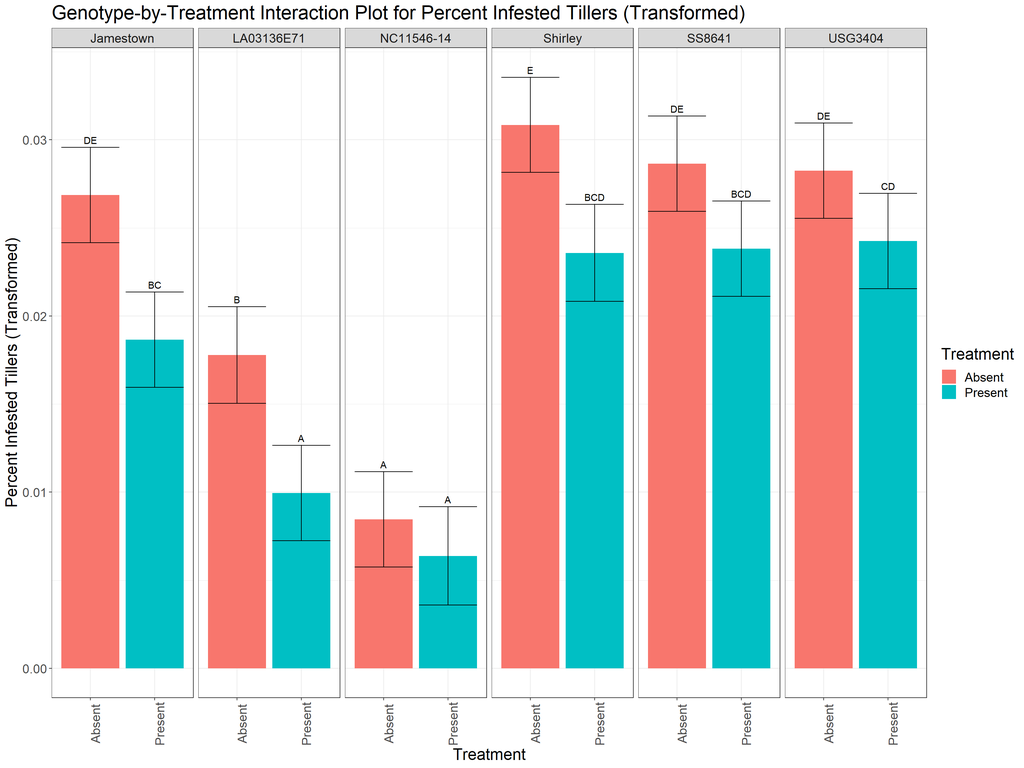

```
## NOTE: Results may be misleading due to involvement in interactions
```

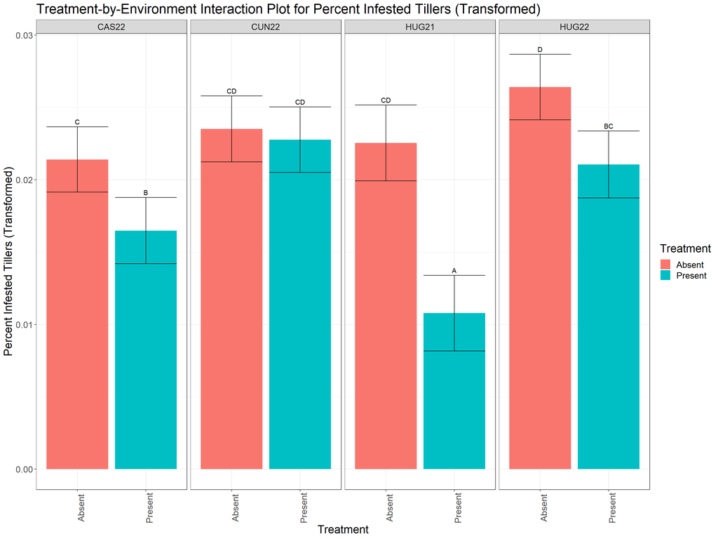

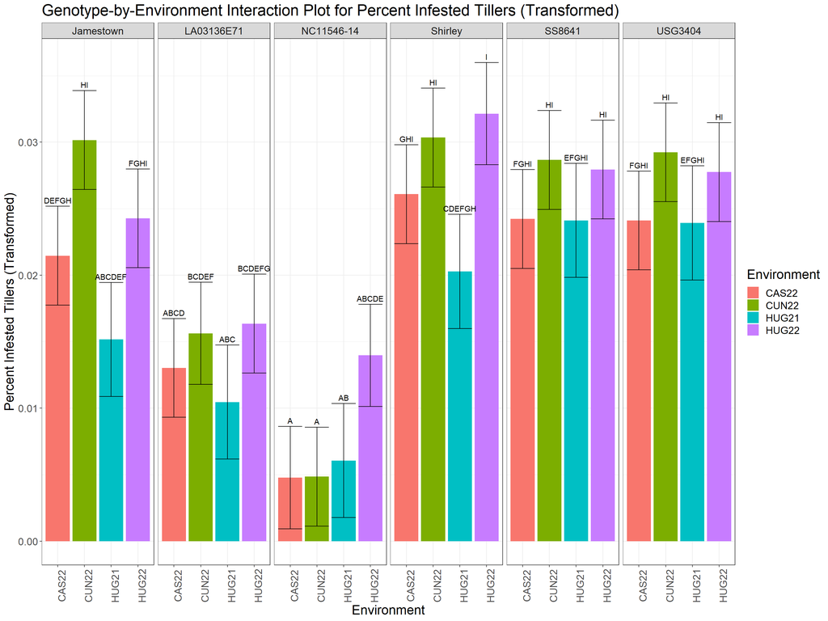

```
## NOTE: Results may be misleading due to involvement in interactions
```

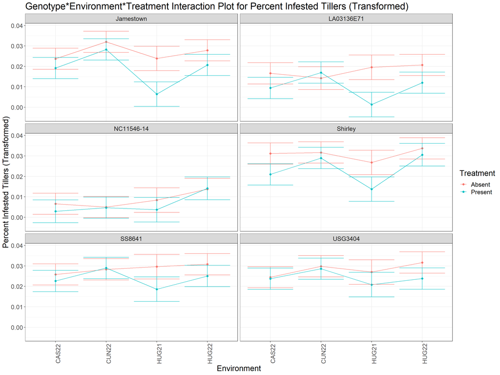

```
## NOTE: Results may be misleading due to involvement in interactions
```

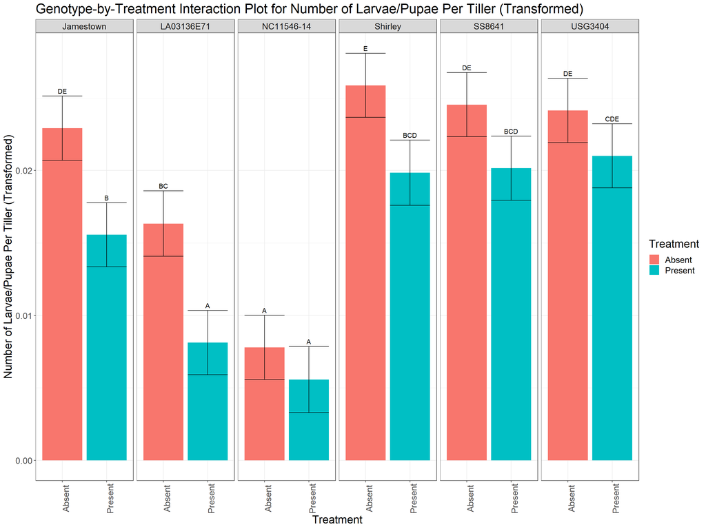

```
## NOTE: Results may be misleading due to involvement in interactions
```

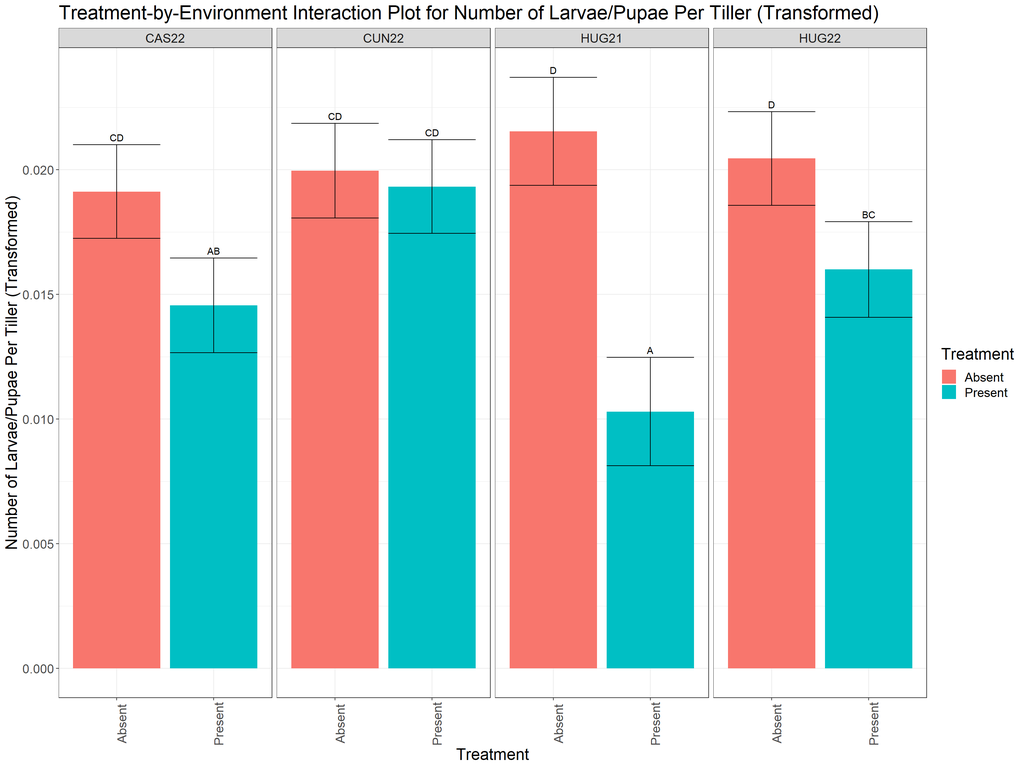

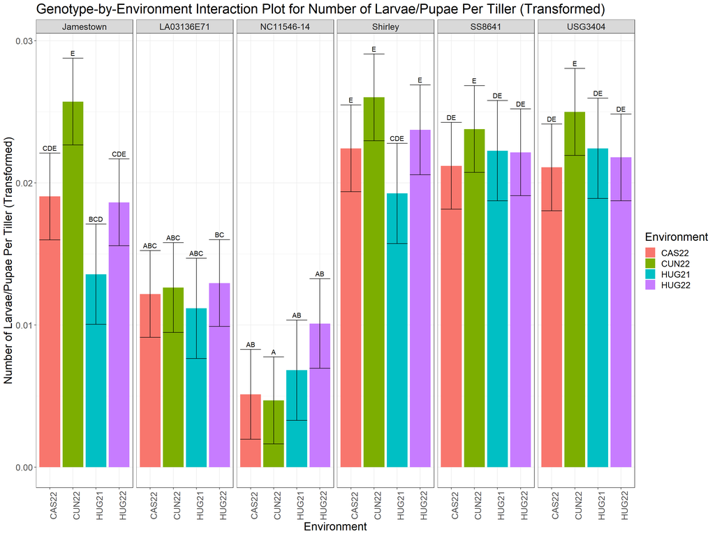

```
## NOTE: Results may be misleading due to involvement in interactions
```

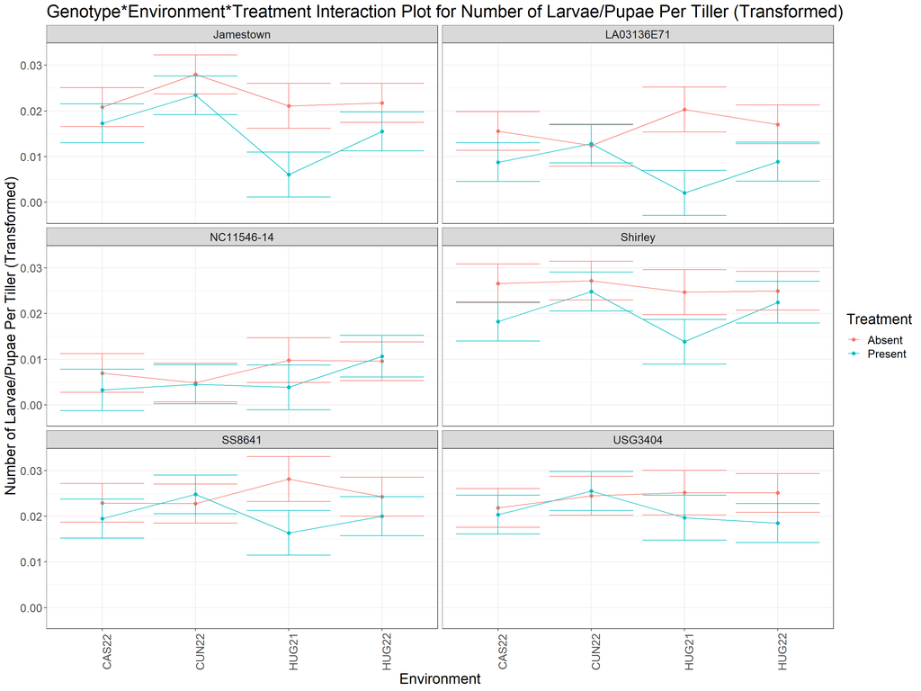

```
## NOTE: Results may be misleading due to involvement in interactions
```

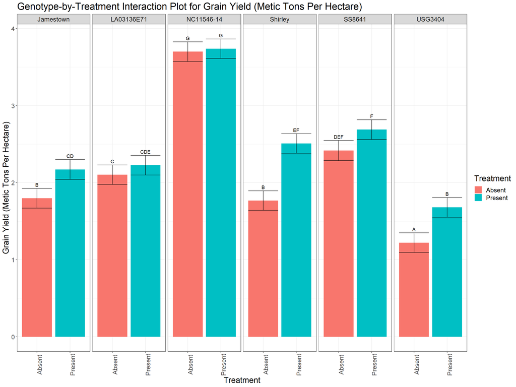

```
## NOTE: Results may be misleading due to involvement in interactions
```

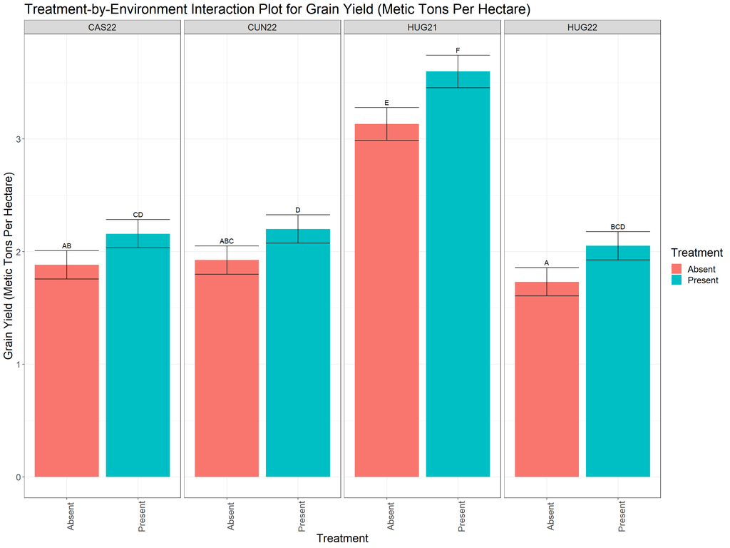

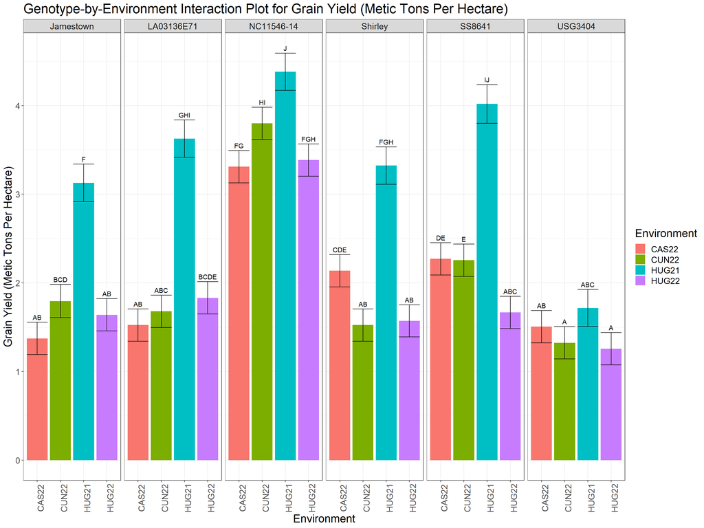

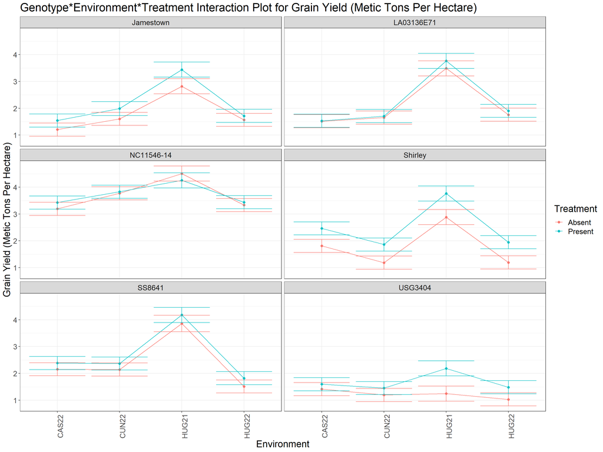